# 5) Refining the results

Hugo Flávio

2019-07-13

## Index

1. Preparing your data
   1. Structuring the study area
   2. Creating a distances matrix
2. Running actel
3. What is actel doing?
   1. Errors and messages
4. Inspecting the results
5. **Refining the results**

## Refining the results

As you inspect your results, you may find out that you would rather change a specific result. For example, perhaps a detection was discarded that is actually relevant, or there are detections that clearly match a predator’s behaviour rather than your fish and actel didn’t pick that up.

When this happens, it is time to take the lead and tell actel what you want to do, by triggering the manual processing mode. To do this, simply add the transmitters that you want to deal with manually in the `override` variable of the actel function (e.g. `override = c("R64K-1234","R64K-1405")`).

When you list tags in `override`, actel will recognise them and enter manual mode. You will know this is happening when you see the following message:

```
----------------------------
M: Override has been triggered for fish R64K-1234. Entering full manual mode.
Opening movements list for inspection.

[...]

Last [section] event:
```

You must then select which event you would like to be considered the **last** event for each section. If a fish did not pass through a given section, press Enter without any answer. You will be asked to confirm your choice:

```
Last [section] event:
Confirm that the fish did not pass this section?(y/N)
```

Once the last events have been selected, you will have to select the **first** events:

```
First [section] event:
```

If previously you indicated that the fish did not leave a given section, the selection of first event for that section will automatically be skipped:

```
M: Skipping first event selection for [section] as this fish never left this section.
```

Once you have selected all the required events, actel will automatically terminate manual mode and assign the fish fate based on the events you selected.

```
First [section] event: 21
Terminating full manual mode
----------------------------
```

And that is it! Repeat the process for all the tags that you want to manually assign, and you will have your refined results.

## Corrected actel report

When you trigger the manual mode, actel will flag the results and report as having been corrected. As such, the output files are no longer called “actel_report.pdf” and “actel_results.RData” but instead “actel_report_corrected.pdf” and “actel_results_corrected.RData”.

On top of that, the graphics for fish that have been manually overriden will be highlighted in red, so you can quickly find them. Below you can see the difference between the original graphic (on the left) and the manually overriden version (on the right):

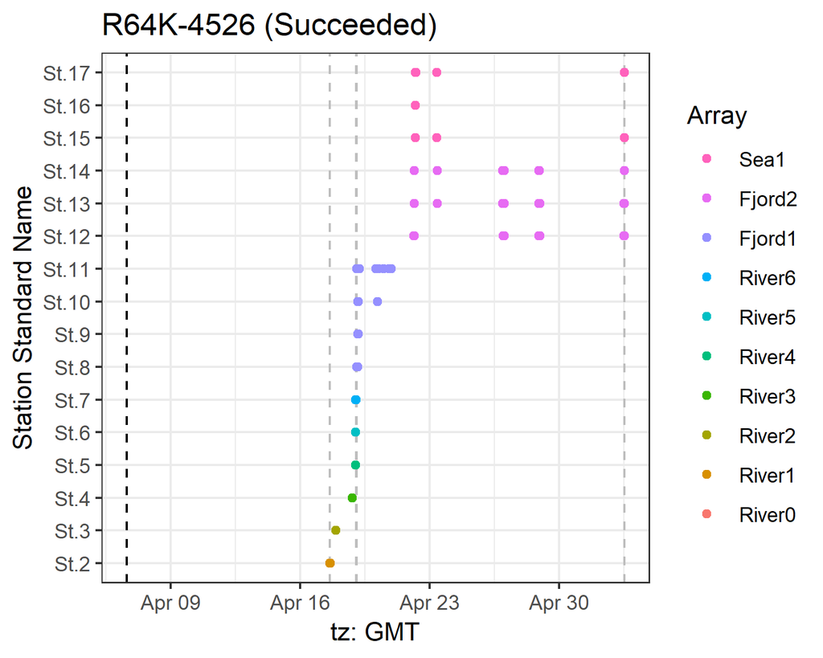

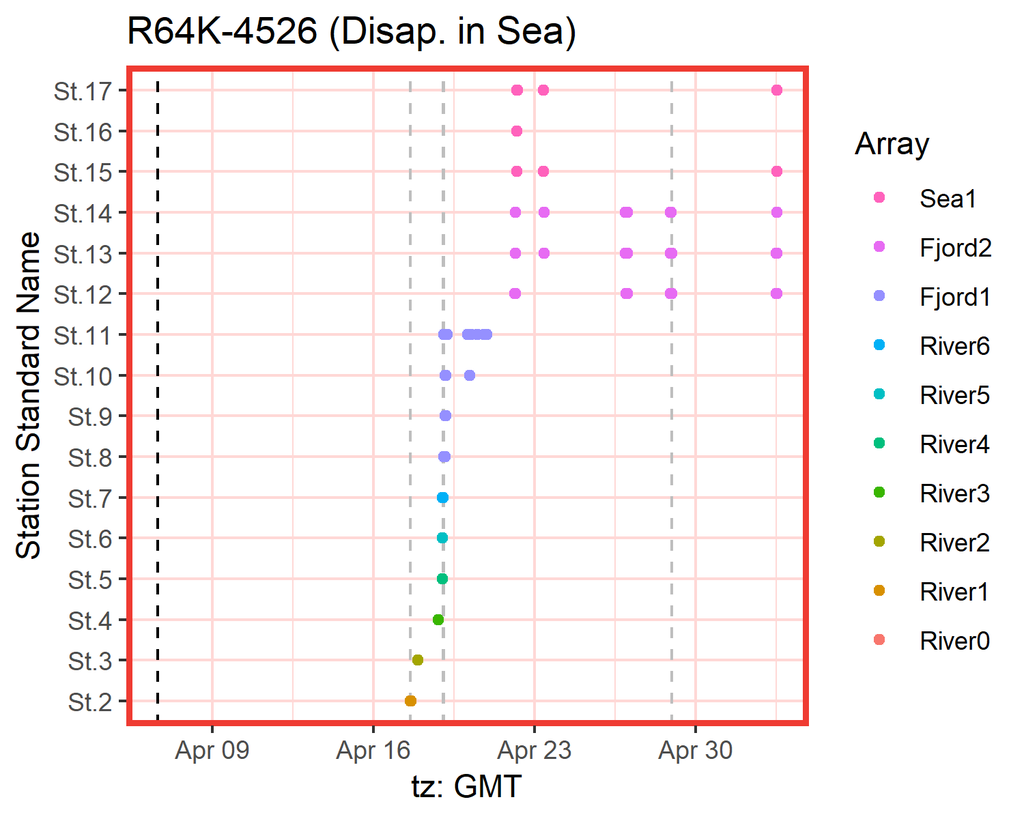

Back to top.